# JHU Practical Machine Learning - Course Project

mb

July 26, 2015

## BACKGROUND

Using devices such as Jawbone Up, Nike FuelBand, and Fitbit it is now possible to collect a large amount of data about personal activity relatively inexpensively. These type of devices are part of the quantified self movement – a group of enthusiasts who take measurements about themselves regularly to improve their health, to find patterns in their behavior, or because they are tech geeks. One thing that people regularly do is quantify how much of a particular activity they do, but they rarely quantify how well they do it. In this project, your goal will be to use data from accelerometers on the belt, forearm, arm, and dumbell of 6 participants. They were asked to perform barbell lifts correctly and incorrectly in 5 different ways. More information is available from the website here: http://groupware.les.inf.puc-rio.br/har (see the section on the Weight Lifting Exercise Dataset).

## DATA

The training data for this project are available here:

https://d396qusza40orc.cloudfront.net/predmachlearn/pml-training.csv

The test data are available here:

https://d396qusza40orc.cloudfront.net/predmachlearn/pml-testing.csv

The data for this project come from this source: http://groupware.les.inf.puc-rio.br/har.

## OBJECTIVES

The goal of the project is to predict the manner in which they did the exercise. This is the “classe” variable in the training set.

- create a report describing how you built your model
- how you used cross validation
- what you think the expected out of sample error is
- why you made the choices you did. You will also use your prediction model to predict 20 different test cases.

## I. LOADING AND CLEANING THE DATA

Upon initial examination of the training data, based on the structure and summar there are several variables with missing values.

```r
#.csv files are stored in the working directory
training = read.csv("pml-training.csv")
str(training)
summary(training)
```

[output not shown]

To address this, both the training and testing data will be loaded into R - adding a special string of characters that represent the missing entries using the na.strings option.

All variables with missing values shall be omitted.

```r
#loading data
training = read.csv("pml-training.csv", na.strings = c("NA","#DIV/0!",""))
testing = read.csv("pml-testing.csv", na.strings = c("NA","#DIV/0!",""))


#identifying variables without missing values
cols = colSums(is.na(training))
cols_nmv <- which(cols==0)

#create new data frames containing variables with complete entries
#removing irrelevant variables
training2 = training[,cols_nmv]
training2 = training2[,c(-5:-3,-1)]
testing2 = testing[,cols_nmv]
testing2 = testing2[,c(-5:-3,-1)]

#check dimensions of the data and take a look of the new dataset
dim(training2); dim(testing2)
```

```
## [1] 19622    56
```

```
## [1] 20 56
```

```r
head(training2); head(testing2)
```

```
##   user_name new_window num_window roll_belt pitch_belt yaw_belt
## 1  carlitos         no         11      1.41       8.07    -94.4
## 2  carlitos         no         11      1.41       8.07    -94.4
## 3  carlitos         no         11      1.42       8.07    -94.4
## 4  carlitos         no         12      1.48       8.05    -94.4
## 5  carlitos         no         12      1.48       8.07    -94.4
## 6  carlitos         no         12      1.45       8.06    -94.4
##   total_accel_belt gyros_belt_x gyros_belt_y gyros_belt_z accel_belt_x
## 1                3         0.00         0.00        -0.02          -21
## 2                3         0.02         0.00        -0.02          -22
## 3                3         0.00         0.00        -0.02          -20
## 4                3         0.02         0.00        -0.03          -22
## 5                3         0.02         0.02        -0.02          -21
## 6                3         0.02         0.00        -0.02          -21
##   accel_belt_y accel_belt_z magnet_belt_x magnet_belt_y magnet_belt_z
```

[output cut: 69 more lines]

```
##   user_name new_window num_window roll_belt pitch_belt yaw_belt
## 1     pedro         no         74    123.00      27.00    -4.75
## 2    jeremy         no        431      1.02       4.87   -88.90
## 3    jeremy         no        439      0.87       1.82   -88.50
## 4    adelmo         no        194    125.00     -41.60   162.00
## 5    eurico         no        235      1.35       3.33   -88.60
## 6    jeremy         no        504     -5.92       1.59   -87.70
##   total_accel_belt gyros_belt_x gyros_belt_y gyros_belt_z accel_belt_x
## 1               20        -0.50        -0.02        -0.46          -38
## 2                4        -0.06        -0.02        -0.07          -13
## 3                5         0.05         0.02         0.03            1
## 4               17         0.11         0.11        -0.16           46
## 5                3         0.03         0.02         0.00           -8
## 6                4         0.10         0.05        -0.13          -11
##   accel_belt_y accel_belt_z magnet_belt_x magnet_belt_y magnet_belt_z
```

[output cut: 69 more lines]

## II. CROSS-VALIDATION

Using the Caret package, partitioning the training dataset for cross-validation.

Splitting the training dataset into 60% for subTrain and 40% for subTest.

SubTrain and SubTest datasets both contain 56 variables with 11776 and 7846 observations, respectively.

```r
library(caret)
set.seed(807)
inTrain = createDataPartition(y=training2$classe, p = 0.6, list = FALSE)
subTrain = training2[inTrain,]
subTest = training2[-inTrain,]


dim(subTrain); dim(subTest)
```

```
## [1] 11776    56
```

```
## [1] 7846   56
```

## III. PREDICTION MODEL

Building of prediction models.

### First algorithm used: ‘rpart’ or Decision tree.

```r
set.seed(807)
#loading rpart packages
library(rpart)
library(rpart.plot)
library(caret)

#building the model using the subTrain data
mod1 = train(classe ~ ., method = "rpart", data = subTrain)
#results
mod1
```

```
## CART
##
## 11776 samples
##    55 predictor
##     5 classes: 'A', 'B', 'C', 'D', 'E'
##
## No pre-processing
## Resampling: Bootstrapped (25 reps)
## Summary of sample sizes: 11776, 11776, 11776, 11776, 11776, 11776, ...
## Resampling results across tuning parameters:
##
##   cp          Accuracy   Kappa       Accuracy SD  Kappa SD
##   0.03215472  0.5827998  0.46661920  0.05406478   0.08068730
##   0.04192375  0.5337099  0.39587367  0.06573400   0.10032546
##   0.11212625  0.3225288  0.05768778  0.04035483   0.06134455
##
## Accuracy was used to select the optimal model using  the largest value.
## The final value used for the model was cp = 0.03215472.
```

```r
mod1$finalModel
```

```
## n= 11776
##
## node), split, n, loss, yval, (yprob)
##       * denotes terminal node
##
##  1) root 11776 8428 A (0.28 0.19 0.17 0.16 0.18)
##    2) roll_belt< 130.5 10815 7475 A (0.31 0.21 0.19 0.18 0.11)
##      4) pitch_forearm< -33.95 955    4 A (1 0.0042 0 0 0) *
##      5) pitch_forearm>=-33.95 9860 7471 A (0.24 0.23 0.21 0.2 0.12)
##       10) num_window>=45.5 9399 7010 A (0.25 0.24 0.22 0.19 0.09)
##         20) magnet_dumbbell_y< 443.5 8048 5701 A (0.29 0.19 0.25 0.18 0.085)
##           40) num_window< 241.5 1868  773 A (0.59 0.15 0.12 0.12 0.031) *
##           41) num_window>=241.5 6180 4402 C (0.2 0.2 0.29 0.2 0.1)
##             82) magnet_dumbbell_z< -27.5 1421  496 A (0.65 0.22 0.057 0.059 0.011) *
##             83) magnet_dumbbell_z>=-27.5 4759 3062 C (0.069 0.2 0.36 0.25 0.13) *
##         21) magnet_dumbbell_y>=443.5 1351  611 B (0.031 0.55 0.045 0.26 0.12) *
##       11) num_window< 45.5 461   99 E (0 0 0 0.21 0.79) *
##    3) roll_belt>=130.5 961    8 E (0.0083 0 0 0 0.99) *
```

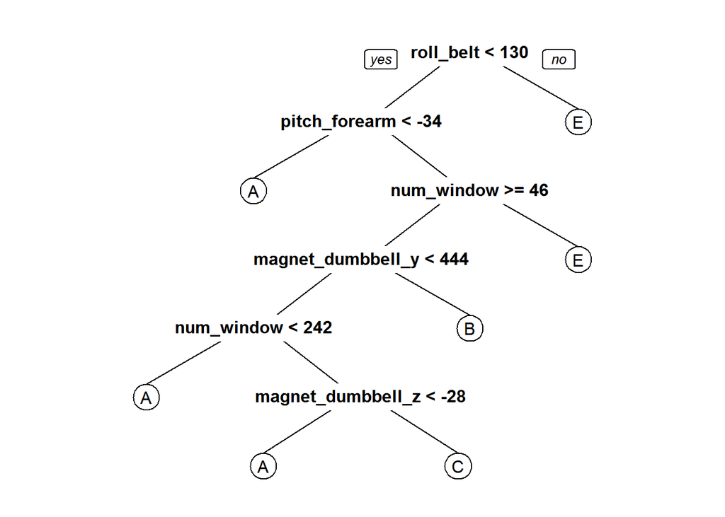

```r
#simple plot
prp(mod1$finalModel)
```

```r
#running predictions using the mod1 on subTest data
pred1 = predict(mod1, subTest)

#confusion matrix for evaluation of the model
confusionMatrix(pred1, subTest$classe)
```

```
## Confusion Matrix and Statistics
##
##           Reference
## Prediction    A    B    C    D    E
##          A 1966  360  226  229   68
##          B   27  512   45  214  104
##          C  233  646 1097  796  381
##          D    0    0    0    0    0
##          E    6    0    0   47  889
##
## Overall Statistics
##
##                Accuracy : 0.569
##                  95% CI : (0.5579, 0.5799)
##     No Information Rate : 0.2845
##     P-Value [Acc > NIR] : < 2.2e-16
##
##                   Kappa : 0.449
##  Mcnemar's Test P-Value : < 2.2e-16
##
## Statistics by Class:
##
##                      Class: A Class: B Class: C Class: D Class: E
## Sensitivity            0.8808  0.33729   0.8019   0.0000   0.6165
## Specificity            0.8427  0.93837   0.6826   1.0000   0.9917
## Pos Pred Value         0.6901  0.56763   0.3479      NaN   0.9437
## Neg Pred Value         0.9468  0.85513   0.9423   0.8361   0.9199
## Prevalence             0.2845  0.19347   0.1744   0.1639   0.1838
## Detection Rate         0.2506  0.06526   0.1398   0.0000   0.1133
## Detection Prevalence   0.3631  0.11496   0.4019   0.0000   0.1201
## Balanced Accuracy      0.8618  0.63783   0.7423   0.5000   0.8041
```

Accuracy is at 0.569. Not sufficient enough to give us confidence on our prediction model, thus we’ll further explore using other algorith such as Random Forest.

### Second Algorithm used: ‘rf’ or Random Forest.

```r
set.seed(807)

#load random forest package
library(randomForest)
#predictors
predictors = names(cols_nmv[c(-5:-3,-1,-60)])
decision = names(cols_nmv[60])

#building model using the subTrain data
mod2 = train(classe ~ ., method = "rf", data = subTrain)
#mod2 = randomForest(subTrain[,predictors], subTrain[,decision])

#results
mod2
```

```
## Random Forest
##
## 11776 samples
##    55 predictor
##     5 classes: 'A', 'B', 'C', 'D', 'E'
##
## No pre-processing
## Resampling: Bootstrapped (25 reps)
## Summary of sample sizes: 11776, 11776, 11776, 11776, 11776, 11776, ...
## Resampling results across tuning parameters:
##
##   mtry  Accuracy   Kappa      Accuracy SD  Kappa SD
##    2    0.9872058  0.9838101  0.002396357  0.003027267
##   30    0.9946240  0.9931987  0.001708753  0.002158624
##   59    0.9907629  0.9883121  0.002973393  0.003761499
##
## Accuracy was used to select the optimal model using  the largest value.
## The final value used for the model was mtry = 30.
```

```r
mod2$finalModel
```

```
##
## Call:
##  randomForest(x = x, y = y, mtry = param$mtry)
##                Type of random forest: classification
##                      Number of trees: 500
## No. of variables tried at each split: 30
##
##         OOB estimate of  error rate: 0.2%
## Confusion matrix:
##      A    B    C    D    E  class.error
## A 3347    1    0    0    0 0.0002986858
## B    4 2273    2    0    0 0.0026327337
## C    0    2 2052    0    0 0.0009737098
## D    0    0    8 1921    1 0.0046632124
## E    0    0    1    5 2159 0.0027713626
```

```r
#running predictions using mod2 on subTest data
pred2 = predict(mod2, subTest)

#model evaluation
confusionMatrix(pred2, subTest$classe)
```

```
## Confusion Matrix and Statistics
##
##           Reference
## Prediction    A    B    C    D    E
##          A 2232    7    0    0    0
##          B    0 1510    4    0    2
##          C    0    1 1364    5    0
##          D    0    0    0 1281    2
##          E    0    0    0    0 1438
##
## Overall Statistics
##
##                Accuracy : 0.9973
##                  95% CI : (0.9959, 0.9983)
##     No Information Rate : 0.2845
##     P-Value [Acc > NIR] : < 2.2e-16
##
##                   Kappa : 0.9966
##  Mcnemar's Test P-Value : NA
##
## Statistics by Class:
##
##                      Class: A Class: B Class: C Class: D Class: E
## Sensitivity            1.0000   0.9947   0.9971   0.9961   0.9972
## Specificity            0.9988   0.9991   0.9991   0.9997   1.0000
## Pos Pred Value         0.9969   0.9960   0.9956   0.9984   1.0000
## Neg Pred Value         1.0000   0.9987   0.9994   0.9992   0.9994
## Prevalence             0.2845   0.1935   0.1744   0.1639   0.1838
## Detection Rate         0.2845   0.1925   0.1738   0.1633   0.1833
## Detection Prevalence   0.2854   0.1932   0.1746   0.1635   0.1833
## Balanced Accuracy      0.9994   0.9969   0.9981   0.9979   0.9986
```

## DECISION

Applying the random forest prediction model to the testing set.

```r
#applying the mod2 (random forest model) on our testing set
pred3 = predict(mod2, testing2)
pred3
```

```
##  [1] B A B A A E D B A A B C B A E E A B B B
## Levels: A B C D E
```

## SUBMISSION

```r
#storing predictions to 'answers' variable
answers = pred3

#writing answers to text document
pml_write_files = function(x){
n = length(x)
for(i in 1:n){
filename = paste0("problem_id_",i,".txt")
write.table(x[i],file=filename,quote=FALSE,row.names=FALSE,col.names=FALSE)
}
}

pml_write_files(answers)
```